# chapter4

Jukka Lankinen

2022-11-29

# Assignment 4: Clustering and classification

## Analysis

This week we delved into clustering and classification. Clustering means that some of the observations are close to each other than some other points. In other words the data points aren’t comprised of a homogeneous sample but they’re somehow clustered.

### 1. Overview of Boston dataset

This week’s dataset is ‘Boston’ dataset from the MASS library. The dataset has 506 rows and 14 columns/variables in which each row represents a suburb of Boston. The dataframe contains various statistics of each areas’ people, tax rates, crime rates, proportion of business acres etc. Description of each variable can be found [here](https://stat.ethz.ch/R-manual/R-devel/library/MASS/html/Boston.html).

```r
# Loading MASS for the dataset
library(MASS)
library(tidyverse)
```

```r
library(ggplot2)
library(GGally)
# load the data
data("Boston")

# explore the dataset
str(Boston)
```

```
## 'data.frame':    506 obs. of  14 variables:
##  $ crim   : num  0.00632 0.02731 0.02729 0.03237 0.06905 ...
##  $ zn     : num  18 0 0 0 0 0 12.5 12.5 12.5 12.5 ...
##  $ indus  : num  2.31 7.07 7.07 2.18 2.18 2.18 7.87 7.87 7.87 7.87 ...
##  $ chas   : int  0 0 0 0 0 0 0 0 0 0 ...
##  $ nox    : num  0.538 0.469 0.469 0.458 0.458 0.458 0.524 0.524 0.524 0.524 ...
##  $ rm     : num  6.58 6.42 7.18 7 7.15 ...
##  $ age    : num  65.2 78.9 61.1 45.8 54.2 58.7 66.6 96.1 100 85.9 ...
##  $ dis    : num  4.09 4.97 4.97 6.06 6.06 ...
##  $ rad    : int  1 2 2 3 3 3 5 5 5 5 ...
##  $ tax    : num  296 242 242 222 222 222 311 311 311 311 ...
##  $ ptratio: num  15.3 17.8 17.8 18.7 18.7 18.7 15.2 15.2 15.2 15.2 ...
##  $ black  : num  397 397 393 395 397 ...
##  $ lstat  : num  4.98 9.14 4.03 2.94 5.33 ...
##  $ medv   : num  24 21.6 34.7 33.4 36.2 28.7 22.9 27.1 16.5 18.9 ...
```

```r
summary(Boston)
```

```
##       crim                zn             indus            chas
##  Min.   : 0.00632   Min.   :  0.00   Min.   : 0.46   Min.   :0.00000
##  1st Qu.: 0.08205   1st Qu.:  0.00   1st Qu.: 5.19   1st Qu.:0.00000
##  Median : 0.25651   Median :  0.00   Median : 9.69   Median :0.00000
##  Mean   : 3.61352   Mean   : 11.36   Mean   :11.14   Mean   :0.06917
##  3rd Qu.: 3.67708   3rd Qu.: 12.50   3rd Qu.:18.10   3rd Qu.:0.00000
##  Max.   :88.97620   Max.   :100.00   Max.   :27.74   Max.   :1.00000
##       nox               rm             age              dis
##  Min.   :0.3850   Min.   :3.561   Min.   :  2.90   Min.   : 1.130
##  1st Qu.:0.4490   1st Qu.:5.886   1st Qu.: 45.02   1st Qu.: 2.100
##  Median :0.5380   Median :6.208   Median : 77.50   Median : 3.207
##  Mean   :0.5547   Mean   :6.285   Mean   : 68.57   Mean   : 3.795
##  3rd Qu.:0.6240   3rd Qu.:6.623   3rd Qu.: 94.08   3rd Qu.: 5.188
##  Max.   :0.8710   Max.   :8.780   Max.   :100.00   Max.   :12.127
##       rad              tax           ptratio          black
##  Min.   : 1.000   Min.   :187.0   Min.   :12.60   Min.   :  0.32
##  1st Qu.: 4.000   1st Qu.:279.0   1st Qu.:17.40   1st Qu.:375.38
##  Median : 5.000   Median :330.0   Median :19.05   Median :391.44
##  Mean   : 9.549   Mean   :408.2   Mean   :18.46   Mean   :356.67
##  3rd Qu.:24.000   3rd Qu.:666.0   3rd Qu.:20.20   3rd Qu.:396.23
##  Max.   :24.000   Max.   :711.0   Max.   :22.00   Max.   :396.90
##      lstat            medv
##  Min.   : 1.73   Min.   : 5.00
##  1st Qu.: 6.95   1st Qu.:17.02
##  Median :11.36   Median :21.20
##  Mean   :12.65   Mean   :22.53
##  3rd Qu.:16.95   3rd Qu.:25.00
##  Max.   :37.97   Max.   :50.00
```

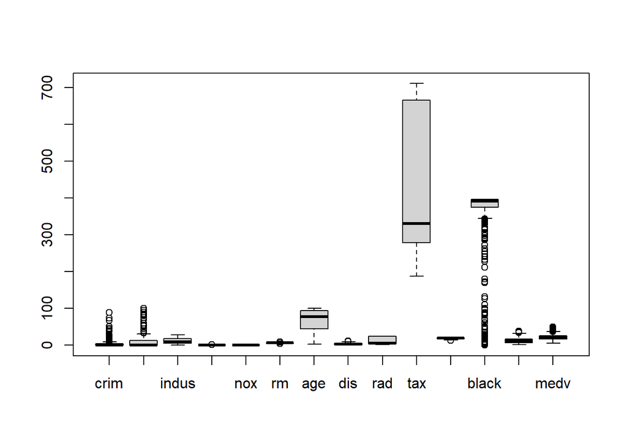

```r
# plot matrix of the variables
boxplot(Boston)
```

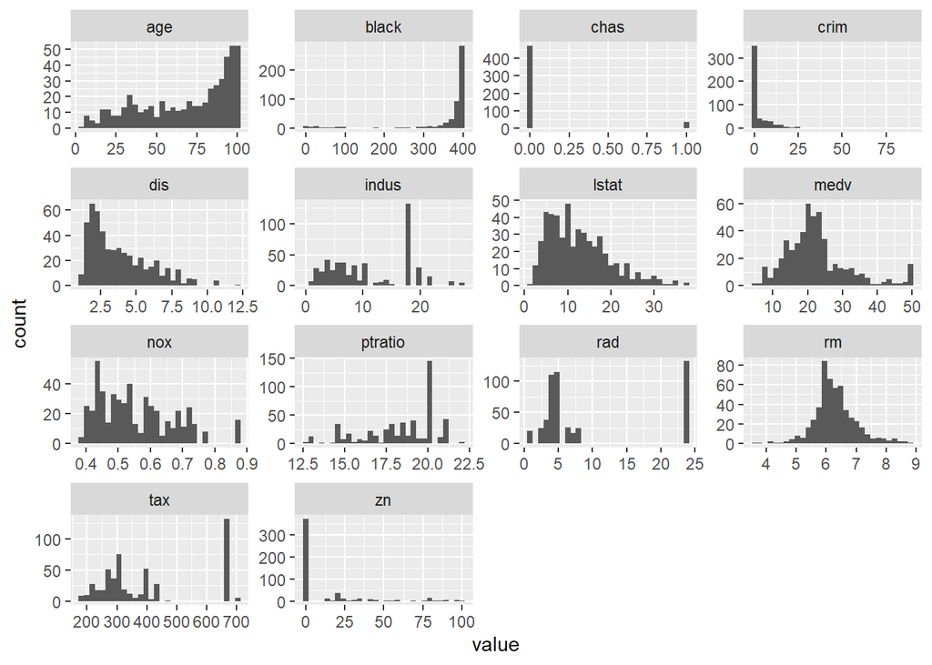

```r
#summaries graphically
Boston %>%
gather(key = "var", value = "value") %>%
ggplot(aes(x = value)) +
geom_histogram() +
facet_wrap(~ var, scales = "free")
```

The median of proportion of owned-occupied (age) units build prior to 1940 is 77.5 so the housing stock is fairly old overall. The median value of owner-occupied homes in $1000s (medv) histogram shows us that there’s a sudden drop of amount of high priced houses after roughly 25k usd. The average number of rooms per dwelling looks like it’s a bit right-skewed and suburb housing markets seem to cater those who need around 6 rooms.

Let’s use corrplot library to graphically to also show the correlation coefficients between variables:

```r
library(corrplot)
round(cor(Boston),1)
```

```
##         crim   zn indus chas  nox   rm  age  dis  rad  tax ptratio black lstat
## crim     1.0 -0.2   0.4 -0.1  0.4 -0.2  0.4 -0.4  0.6  0.6     0.3  -0.4   0.5
## zn      -0.2  1.0  -0.5  0.0 -0.5  0.3 -0.6  0.7 -0.3 -0.3    -0.4   0.2  -0.4
## indus    0.4 -0.5   1.0  0.1  0.8 -0.4  0.6 -0.7  0.6  0.7     0.4  -0.4   0.6
## chas    -0.1  0.0   0.1  1.0  0.1  0.1  0.1 -0.1  0.0  0.0    -0.1   0.0  -0.1
## nox      0.4 -0.5   0.8  0.1  1.0 -0.3  0.7 -0.8  0.6  0.7     0.2  -0.4   0.6
## rm      -0.2  0.3  -0.4  0.1 -0.3  1.0 -0.2  0.2 -0.2 -0.3    -0.4   0.1  -0.6
## age      0.4 -0.6   0.6  0.1  0.7 -0.2  1.0 -0.7  0.5  0.5     0.3  -0.3   0.6
## dis     -0.4  0.7  -0.7 -0.1 -0.8  0.2 -0.7  1.0 -0.5 -0.5    -0.2   0.3  -0.5
## rad      0.6 -0.3   0.6  0.0  0.6 -0.2  0.5 -0.5  1.0  0.9     0.5  -0.4   0.5
## tax      0.6 -0.3   0.7  0.0  0.7 -0.3  0.5 -0.5  0.9  1.0     0.5  -0.4   0.5
## ptratio  0.3 -0.4   0.4 -0.1  0.2 -0.4  0.3 -0.2  0.5  0.5     1.0  -0.2   0.4
## black   -0.4  0.2  -0.4  0.0 -0.4  0.1 -0.3  0.3 -0.4 -0.4    -0.2   1.0  -0.4
## lstat    0.5 -0.4   0.6 -0.1  0.6 -0.6  0.6 -0.5  0.5  0.5     0.4  -0.4   1.0
## medv    -0.4  0.4  -0.5  0.2 -0.4  0.7 -0.4  0.2 -0.4 -0.5    -0.5   0.3  -0.7
##         medv
## crim    -0.4
## zn       0.4
## indus   -0.5
## chas     0.2
## nox     -0.4
## rm       0.7
## age     -0.4
## dis      0.2
## rad     -0.4
## tax     -0.5
## ptratio -0.5
## black    0.3
## lstat   -0.7
## medv     1.0
```

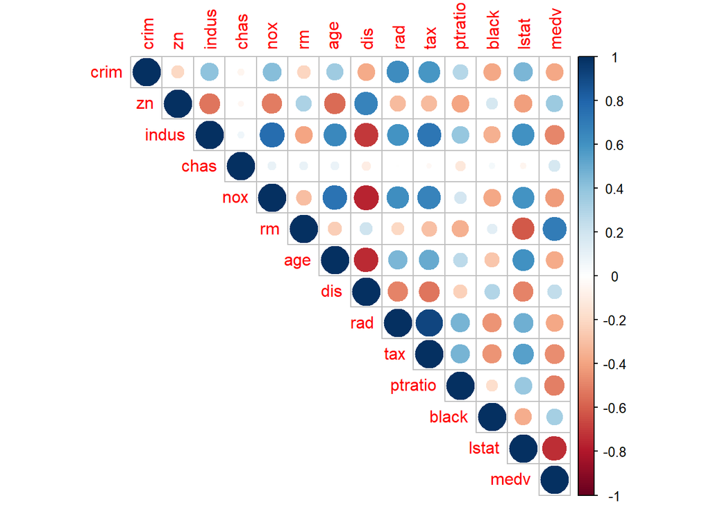

```r
corrplot(cor(Boston),
         type="upper",
         )
```

Correlation coefficients give us values between -1 and 1. Positive correlation (0 to 1) means that when one variable changes, the other variable changes to same direction. Negative correlation (-1 to 0) means that the other variable goes to the opposite direction. 0 valua means no correlation.

From correlations we can see some self-evident correlations such as the strong negative correlation of nitrogen oxides concentration (nox) and weighted mean distances to Five Boston employment centres (dis). The longer the distance from high traffic zones the less nitrogen oxides are in the area. Obviously the (nox) correlates strongly (and positively) with proportion of non-retail business acres per town (indus). Factories typically produce more emissions so more nitrogen oxides in those suburbs. Interestingly there’s also a strong positive correlation between accessibility to radial highways (rad) and full-value property tax-rate per $10000 (tax).

Biggest correlations to crime rate are interestingly the before-mentioned full-value property-tax rate per $10000 (tax) and accessibility to radial highways (rad). This is all speculation but this might be due to how crimes could be more likely to be reported in richer areas than in poorer suburbs - how this data was gained is interesting nonetheless.

### 2. Standardizing the dataset

As seen earlier from the box plots the variables get pretty different values so in age, black and tax variables compared to the rest so it’d wise to scale the whole dataset. Function scale() scales the dataset like this:

$$scaled(x) = \frac{x - mean(x)}{
sd(x)}$$

```r
# center and standardize variables
boston_scaled <- scale(Boston)

# summaries of the scaled variables
summary(boston_scaled)
```

```
##       crim                 zn               indus              chas
##  Min.   :-0.419367   Min.   :-0.48724   Min.   :-1.5563   Min.   :-0.2723
##  1st Qu.:-0.410563   1st Qu.:-0.48724   1st Qu.:-0.8668   1st Qu.:-0.2723
##  Median :-0.390280   Median :-0.48724   Median :-0.2109   Median :-0.2723
##  Mean   : 0.000000   Mean   : 0.00000   Mean   : 0.0000   Mean   : 0.0000
##  3rd Qu.: 0.007389   3rd Qu.: 0.04872   3rd Qu.: 1.0150   3rd Qu.:-0.2723
##  Max.   : 9.924110   Max.   : 3.80047   Max.   : 2.4202   Max.   : 3.6648
##       nox                rm               age               dis
##  Min.   :-1.4644   Min.   :-3.8764   Min.   :-2.3331   Min.   :-1.2658
##  1st Qu.:-0.9121   1st Qu.:-0.5681   1st Qu.:-0.8366   1st Qu.:-0.8049
##  Median :-0.1441   Median :-0.1084   Median : 0.3171   Median :-0.2790
##  Mean   : 0.0000   Mean   : 0.0000   Mean   : 0.0000   Mean   : 0.0000
##  3rd Qu.: 0.5981   3rd Qu.: 0.4823   3rd Qu.: 0.9059   3rd Qu.: 0.6617
##  Max.   : 2.7296   Max.   : 3.5515   Max.   : 1.1164   Max.   : 3.9566
##       rad               tax             ptratio            black
##  Min.   :-0.9819   Min.   :-1.3127   Min.   :-2.7047   Min.   :-3.9033
##  1st Qu.:-0.6373   1st Qu.:-0.7668   1st Qu.:-0.4876   1st Qu.: 0.2049
##  Median :-0.5225   Median :-0.4642   Median : 0.2746   Median : 0.3808
##  Mean   : 0.0000   Mean   : 0.0000   Mean   : 0.0000   Mean   : 0.0000
##  3rd Qu.: 1.6596   3rd Qu.: 1.5294   3rd Qu.: 0.8058   3rd Qu.: 0.4332
##  Max.   : 1.6596   Max.   : 1.7964   Max.   : 1.6372   Max.   : 0.4406
##      lstat              medv
##  Min.   :-1.5296   Min.   :-1.9063
##  1st Qu.:-0.7986   1st Qu.:-0.5989
##  Median :-0.1811   Median :-0.1449
##  Mean   : 0.0000   Mean   : 0.0000
##  3rd Qu.: 0.6024   3rd Qu.: 0.2683
##  Max.   : 3.5453   Max.   : 2.9865
```

```r
# change the object to data frame
boston_scaled <- as.data.frame(boston_scaled)
```

Every variable now has a mean of 0 as seen from the summary.

#### Creation of categorical variable

Let’s make a categorical variable of the crime rate in Boston by first creating a quantile vector and then creating the actual variable with labes “low”, “med_low”, “med_high” and “high”. After that we remove the original crim variable from the data frame and add the categorical value.

```r
# Work with the exercise in this chunk, step-by-step. Fix the R code!
# Boston and boston_scaled are available

# summary of the scaled crime rate
summary(boston_scaled$crim)
```

```
##      Min.   1st Qu.    Median      Mean   3rd Qu.      Max.
## -0.419367 -0.410563 -0.390280  0.000000  0.007389  9.924110
```

```r
# create a quantile vector of crim and print it
bins <- quantile(boston_scaled$crim)
bins
```

```
##           0%          25%          50%          75%         100%
## -0.419366929 -0.410563278 -0.390280295  0.007389247  9.924109610
```

```r
# create a categorical variable 'crime'
crime <- cut(boston_scaled$crim, breaks = bins, labels = c("low", "med_low", "med_high", "high"), include.lowest = TRUE)

# look at the table of the new factor crime


# remove original crim from the dataset
boston_scaled <- dplyr::select(boston_scaled, -crim)

# add the new categorical value to scaled data
boston_scaled <- data.frame(boston_scaled, crime)

summary(boston_scaled)
```

```
##        zn               indus              chas              nox
##  Min.   :-0.48724   Min.   :-1.5563   Min.   :-0.2723   Min.   :-1.4644
##  1st Qu.:-0.48724   1st Qu.:-0.8668   1st Qu.:-0.2723   1st Qu.:-0.9121
##  Median :-0.48724   Median :-0.2109   Median :-0.2723   Median :-0.1441
##  Mean   : 0.00000   Mean   : 0.0000   Mean   : 0.0000   Mean   : 0.0000
##  3rd Qu.: 0.04872   3rd Qu.: 1.0150   3rd Qu.:-0.2723   3rd Qu.: 0.5981
##  Max.   : 3.80047   Max.   : 2.4202   Max.   : 3.6648   Max.   : 2.7296
##        rm               age               dis               rad
##  Min.   :-3.8764   Min.   :-2.3331   Min.   :-1.2658   Min.   :-0.9819
##  1st Qu.:-0.5681   1st Qu.:-0.8366   1st Qu.:-0.8049   1st Qu.:-0.6373
##  Median :-0.1084   Median : 0.3171   Median :-0.2790   Median :-0.5225
##  Mean   : 0.0000   Mean   : 0.0000   Mean   : 0.0000   Mean   : 0.0000
##  3rd Qu.: 0.4823   3rd Qu.: 0.9059   3rd Qu.: 0.6617   3rd Qu.: 1.6596
##  Max.   : 3.5515   Max.   : 1.1164   Max.   : 3.9566   Max.   : 1.6596
##       tax             ptratio            black             lstat
##  Min.   :-1.3127   Min.   :-2.7047   Min.   :-3.9033   Min.   :-1.5296
##  1st Qu.:-0.7668   1st Qu.:-0.4876   1st Qu.: 0.2049   1st Qu.:-0.7986
##  Median :-0.4642   Median : 0.2746   Median : 0.3808   Median :-0.1811
##  Mean   : 0.0000   Mean   : 0.0000   Mean   : 0.0000   Mean   : 0.0000
##  3rd Qu.: 1.5294   3rd Qu.: 0.8058   3rd Qu.: 0.4332   3rd Qu.: 0.6024
##  Max.   : 1.7964   Max.   : 1.6372   Max.   : 0.4406   Max.   : 3.5453
##       medv              crime
##  Min.   :-1.9063   low     :127
##  1st Qu.:-0.5989   med_low :126
##  Median :-0.1449   med_high:126
##  Mean   : 0.0000   high    :127
##  3rd Qu.: 0.2683
##  Max.   : 2.9865
```

```r
str(boston_scaled)
```

```
## 'data.frame':    506 obs. of  14 variables:
##  $ zn     : num  0.285 -0.487 -0.487 -0.487 -0.487 ...
##  $ indus  : num  -1.287 -0.593 -0.593 -1.306 -1.306 ...
##  $ chas   : num  -0.272 -0.272 -0.272 -0.272 -0.272 ...
##  $ nox    : num  -0.144 -0.74 -0.74 -0.834 -0.834 ...
##  $ rm     : num  0.413 0.194 1.281 1.015 1.227 ...
##  $ age    : num  -0.12 0.367 -0.266 -0.809 -0.511 ...
##  $ dis    : num  0.14 0.557 0.557 1.077 1.077 ...
##  $ rad    : num  -0.982 -0.867 -0.867 -0.752 -0.752 ...
##  $ tax    : num  -0.666 -0.986 -0.986 -1.105 -1.105 ...
##  $ ptratio: num  -1.458 -0.303 -0.303 0.113 0.113 ...
##  $ black  : num  0.441 0.441 0.396 0.416 0.441 ...
##  $ lstat  : num  -1.074 -0.492 -1.208 -1.36 -1.025 ...
##  $ medv   : num  0.16 -0.101 1.323 1.182 1.486 ...
##  $ crime  : Factor w/ 4 levels "low","med_low",..: 1 1 1 1 1 1 2 2 2 2 ...
```

As seen from the summary there’s a new Factor variable “crime” that has 126-127 counts in each category.

#### Creation of data and training set

We’ll divide the dataset to train and test sets in which 80% of the data belongs to the train set. The divide is done randomly and we’ll save the test sets correct crime variables to correct_classes.

```r
# number of rows in the Boston dataset
n <- nrow(boston_scaled)

# choose randomly 80% of the rows
ind <- sample(n,  size = n * 0.8)

# create train set
train <- boston_scaled[ind,]

# create test set
test <- boston_scaled[-ind,]

# save the correct classes from test data
correct_classes <- test$crime

# remove the crime variable from test data
test <- dplyr::select(test, -crime)
```

### 3. Linear Discrimant Analysis

Linear Discrimant Analysis (LDA) is a classification method that is used for modelling differences in groups i.e. separating two or more classes. Below we have fitted the dataset to a LDA model and drawn the LDA model. In this case we want to see how the numerous variables affect crime rate.

```r
# linear discriminant analysis
lda.fit <- lda(crime ~ ., data = train)

# print the lda.fit object
lda.fit
```

```
## Call:
## lda(crime ~ ., data = train)
##
## Prior probabilities of groups:
##       low   med_low  med_high      high
## 0.2425743 0.2475248 0.2574257 0.2524752
##
## Group means:
##                   zn      indus        chas        nox          rm        age
## low       1.02527268 -0.9196949 -0.11163110 -0.8512949  0.43745817 -0.8524796
## med_low  -0.06404285 -0.3218608 -0.03610305 -0.5785071 -0.09349955 -0.3646294
## med_high -0.38746839  0.2530496  0.18195173  0.4460700  0.05298902  0.4407919
## high     -0.48724019  1.0171096 -0.07933396  1.0913388 -0.45659412  0.8071793
##                 dis        rad        tax     ptratio       black      lstat
## low       0.8854016 -0.6900668 -0.7491380 -0.47954401  0.37426328 -0.7926424
## med_low   0.3488530 -0.5454537 -0.4633825 -0.05197987  0.31325605 -0.2044743
## med_high -0.4036864 -0.4010119 -0.2821031 -0.31656283  0.08039048  0.0258411
## high     -0.8535407  1.6382099  1.5141140  0.78087177 -0.87721053  0.9130948
##                 medv
## low       0.52876558
## med_low   0.04068603
## med_high  0.12335419
## high     -0.73621453
##
## Coefficients of linear discriminants:
##                 LD1          LD2         LD3
## zn       0.12834667  0.721050672 -1.03209802
## indus    0.01847162 -0.304165902  0.10590921
## chas    -0.10225789 -0.037650783  0.07939097
## nox      0.38344830 -0.619621764 -1.30428610
## rm      -0.06721364 -0.100563471 -0.18980807
## age      0.30503164 -0.282872266 -0.23694964
## dis     -0.05132906 -0.252841018  0.14092662
## rad      3.00989793  0.966372544 -0.34938711
## tax     -0.04225169 -0.095252671  0.94993122
## ptratio  0.11027932  0.075696939 -0.21973732
## black   -0.13347412 -0.006137594  0.09810469
## lstat    0.26435366 -0.235861677  0.28247005
## medv     0.17506388 -0.323935717 -0.18111419
##
## Proportion of trace:
##    LD1    LD2    LD3
## 0.9434 0.0413 0.0154
```

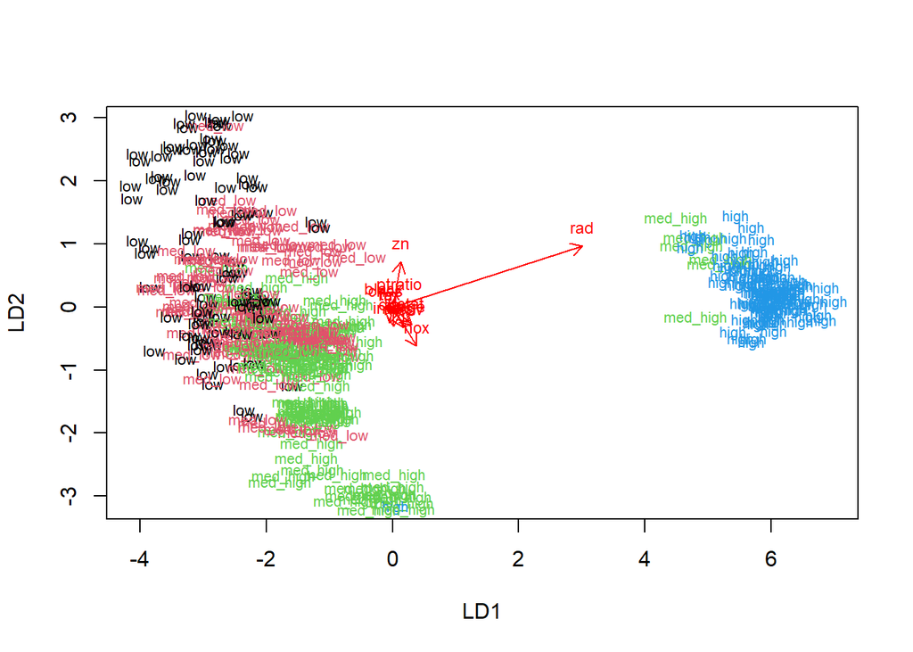

```r
# the function for lda biplot arrows
lda.arrows <- function(x, myscale = 1, arrow_heads = 0.1, color = "red", tex = 0.75, choices = c(1,2)){
  heads <- coef(x)
  arrows(x0 = 0, y0 = 0,
         x1 = myscale * heads[,choices[1]],
         y1 = myscale * heads[,choices[2]], col=color, length = arrow_heads)
  text(myscale * heads[,choices], labels = row.names(heads),
       cex = tex, col=color, pos=3)
}

# target classes as numeric
classes <- as.numeric(train$crime)

# plot the lda results
plot(lda.fit, dimen = 2, col = classes, pch = classes)
lda.arrows(lda.fit, myscale = 1)
```

```r
# predict classes with test data
lda.pred <- predict(lda.fit, newdata = test)
# cross tabulate the results
table(correct = correct_classes, predicted = lda.pred$class)
```

```
##           predicted
## correct    low med_low med_high high
##   low       16      13        0    0
##   med_low    2      20        4    0
##   med_high   0       9       13    0
##   high       0       0        0   25
```

### 4. K-means clustering

Let’s reload the Boston dataset and calculate distances between observations with euclidean and manhattan methods. Euclidean distance is linear distance between two data points in a plane. Manhattan distance is the sum of absolute differences between points in all dimensions, in other words it can be viewed as a zig-zagging ‘city block distance’.

```r
# loading data and standardizing it
data("Boston")
newboston <- scale(Boston)
newboston <- as.data.frame(newboston)

#calculating distances with euclidean and manhattan methods
dist_euc <- dist(newboston, method = "euclidean")
dist_man <- dist(newboston, method = "manhattan")
summary(dist_euc)
```

```
##    Min. 1st Qu.  Median    Mean 3rd Qu.    Max.
##  0.1343  3.4625  4.8241  4.9111  6.1863 14.3970
```

```r
summary(dist_man)
```

```
##    Min. 1st Qu.  Median    Mean 3rd Qu.    Max.
##  0.2662  8.4832 12.6090 13.5488 17.7568 48.8618
```

And the lets run a k-mean algorithm lets investigate.

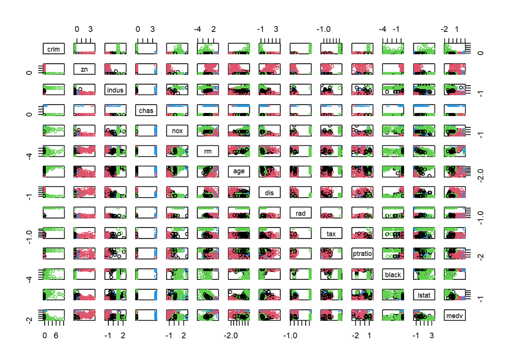

```r
kmean <- kmeans(newboston, centers=4)
pairs(newboston, col = kmean$cluster)
```

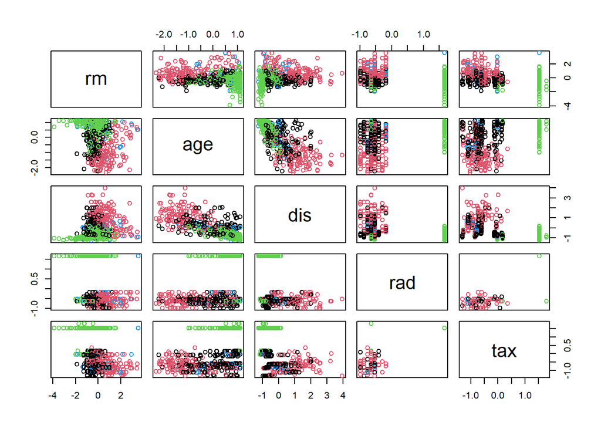

```r
pairs(newboston[6:10], col = kmean$cluster)
```

With this many variables pairs is a bit of a mess but we could show it in smaller ‘doses’ by comparing smaller amounts of columns at once. Let’s determine the optimal amount of clusters:

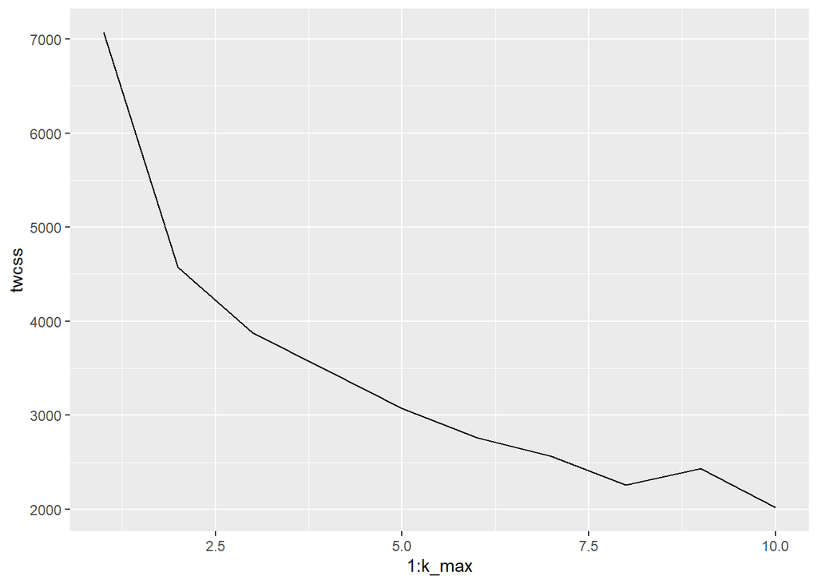

```r
# determine the number of clusters
k_max <- 10

# calculate the total within sum of squares
twcss <- sapply(1:k_max, function(k){kmeans(newboston, k)$tot.withinss})

# visualize the results
qplot(x = 1:k_max, y = twcss, geom = 'line')
```

The twcss value drops radically when clusters go to 2 so this should be the optimal amount of clusters. Let’s plot pairs again with 2 centers.

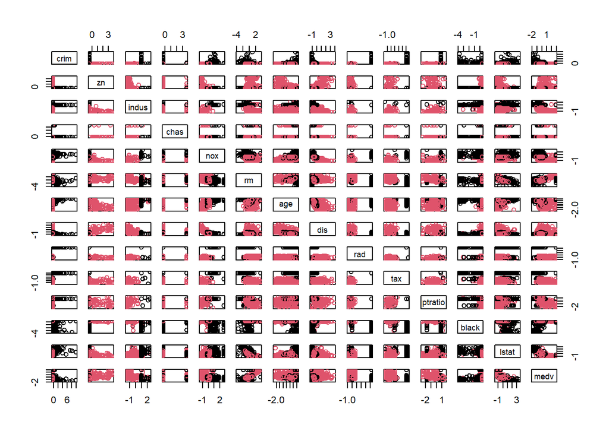

```r
kmean2 <- kmeans(newboston, centers=2)
pairs(newboston, col = kmean2$cluster)
```

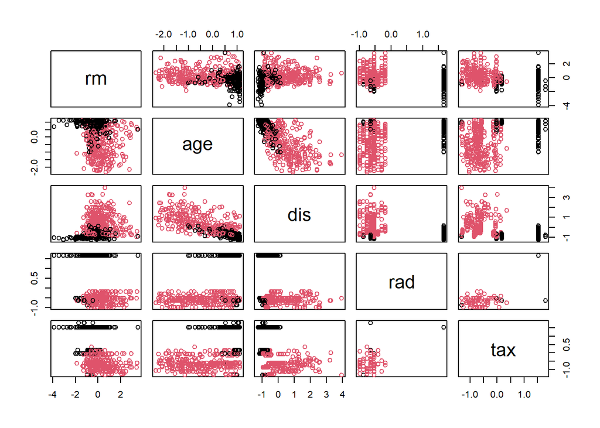

```r
pairs(newboston[6:10], col = kmean2$cluster)
```

The clusters are much more recognizable now and and less overlapping.

## Data wrangling

This time data wrangling exercise was prepwork for next week’s assignemt. As usual you can find the create_human.R script from my repo’s [data folder](https://github.com/jmlankinen/IODS-project/tree/master/data).